# rgl Overview

Duncan Murdoch

March 28, 2018

## Introduction

The `rgl` package is used to produce interactive 3-D plots. It contains high-level graphics commands modelled loosely after classic R graphics, but working in three dimensions. It also contains low level structure inspired by (but incompatible with) the `grid` package.

This document gives an overview. See the help pages for details.

### About this document

This document was written in R Markdown, using the `knitr` package for production. It corresponds to rgl version 0.99.16.

Most of the highlighted function names are HTML links. The internal links should work in any browser; the links to help topics should work if you view the vignette from within the R help system.

The document includes WebGL figures. To view these, you must have Javascript and WebGL enabled in your browser. Some older browsers may not support this – see http://get.webgl.org for tests and links to a discussion.

## Basics and High Level Functions

The `plot3d` function plots points within an rgl window. It is similar to the classic `plot` function, but works in 3 dimensions.

For example

```r
with(iris, plot3d(Sepal.Length, Sepal.Width, Petal.Length,
                  type="s", col=as.numeric(Species)))
```

[interactive chart not shown]

can be used to plot three columns of the `iris` data.  
Allowed plot types include `"p", "l", "h", "s"`, meaning points, lines, segments from z=0, and spheres. There’s a lot of flexibility in specifying the coordinates; the `xyz.coords` function from the `grDevices` package is used for this.

You can use your mouse to manipulate the plot. The default is that if you click and hold with the left mouse button, you can rotate the plot by dragging it. The right mouse button is used to resize it, and the middle button changes the perspective in the point of view.

If you call `plot3d` again, it will overwrite the current plot. To open a new graphics window, use `open3d`.

The other high level function is `persp3d` to draw surfaces. It is similar to the classic `persp` function, but with greater flexibility. First, any of `x`, `y` or `z` can be specified using matrices, not just `z`. This allows parametric surfaces to be plotted. An even simpler specification is possible: `x` may be a function, in which case `persp3d` will work out the grid itself. See ?persp3d.function for details. For example, the `MASS` package estimates Gamma parameters using maximum likelihood in a ?MASS::fitdistr example. Here we show the log likelihood surface.

```r
library(MASS)
# from the fitdistr example
set.seed(123)
x <- rgamma(100, shape = 5, rate = 0.1)
fit <- fitdistr(x, dgamma, list(shape = 1, rate = 0.1), lower = 0.001)
loglik <- function(shape, rate) sum(dgamma(x, shape=shape, rate=rate,
                                           log=TRUE))
loglik <- Vectorize(loglik)
xlim <- fit$estimate[1]+4*fit$sd[1]*c(-1,1)
ylim <- fit$estimate[2]+4*fit$sd[2]*c(-1,1)

mfrow3d(1, 2, sharedMouse = TRUE)
persp3d(loglik,
        xlim = xlim, ylim = ylim,
        n = 30)
zlim <- fit$loglik + c(-qchisq(0.99, 2)/2, 0)
next3d()
persp3d(loglik,
        xlim = xlim, ylim = ylim, zlim = zlim,
        n = 30)
```

[interactive chart not shown]

You must enable Javascript to view this page properly.

On the left, the whole surface over a range of the parameters; on the right, only the parts of the surface with log likelihood values near the maximum.

Note: this example used the `knitr` hook functions (see `setupKnitr`) to insert the scene into this vignette; the previous example used the `rglwidget` function. We generally recommend the newer `rglwidget` approach.

## Adding Graphical Elements

### Primitive shapes

Just as we have `points` and `lines` in classic graphics, there are a number of low level functions in `rgl` to add graphical elements to the currently active plot. The “primitive” shapes are those that are native to OpenGL:

| Function | Description |
| --- | --- |
| `points3d`: | adds points |
| `lines3d`: | adds lines |
| `segments3d`: | adds line segments |
| `triangles3d`: | adds triangles |
| `quads3d`: | adds quadrilaterals |

Each of the above functions takes arguments `x`, `y` and `z`, again using `xyz.coords` for flexibility. They group successive entries as necessary. For example, the `triangles3d` function takes each successive triple of points as the vertices of a triangle.

You can use these functions to annotate the current graph, or to construct a figure from scratch.

### Constructed shapes

`rgl` also has a number of objects which it constructs from the primitives.

| Function | Description |
| --- | --- |
| `text3d`, `texts3d`: | adds text |
| `abclines3d`: | adds straight lines to plot (like `abline`) |
| `planes3d`: | adds planes to plot |
| `clipplanes3d`: | add clipping planes to plot |
| `sprites3d`, `particles3d`: | add sprites (fixed shapes or images) to plot |
| `spheres3d`: | adds spheres |
| `surface3d`, `terrain3d`: | a surface (as used in `persp3d`) |
| `arrow3d`: | add an arrow to a scene |
| `pch3d`: | draw base-style plotting symbols |
| `plotmath3d`: | used by `text3d` for math text |

### Axes and other “decorations”

The following low-level functions control the look of the graph:

| Function | Description |
| --- | --- |
| `axes3d`, `axis3d`: | add axes to plot |
| `box3d`, `bbox3d`: | add box around plot |
| `title3d`: | add title to plot |
| `mtext3d`: | add marginal text to plot |
| `decorate3d`: | add multiple “decorations” (scales, etc.) to plot |
| `aspect3d`: | set the aspect ratios for the plot |
| `bg3d`, `bgplot3d`: | set the background of the scene |
| `show2d`: | show a 2D plot or image in a 3D scene |
| `legend3d`: | set a legend for the scene |
| `grid3d`: | add a reference grid to a graph |

For example, to plot three random triangles, one could use

```r
triangles3d(cbind(x=rnorm(9), y=rnorm(9), z=rnorm(9)), col = "green")
decorate3d()
bg3d("lightgray")
aspect3d(1,1,1)
```

[interactive chart not shown]

You must enable Javascript to view this page properly.

Besides the `*3d` functions mentioned above, there are even lower-level functions `rgl.primitive`, `rgl.points`, `rgl.linestrips`, `rgl.lines`, `rgl.triangles`, `rgl.quads`, `rgl.texts`, `rgl.abclines`, `rgl.planes`, `rgl.bg`, `rgl.clipplanes`, `rgl.bbox`, `rgl.spheres`, `rgl.sprites`, `rgl.surface`.  
You should avoid using these functions, which do not work well with the higher level `*3d` functions. See the ?r3d help topic for details.

## Controlling the Look of the Scene

### Lighting

In most scenes, objects are “lit”, meaning that their appearance depends on their position and orientation relative to lights in the scene. The lights themselves don’t normally show up, but their effect on the objects does.

Use the `light3d` function to specify the position and characteristics of a light. Lights may be infinitely distant, or may be embedded within the scene. Their characteristics include `ambient`, `diffuse`, and `specular` components, all defaulting to white. The `ambient` component appears the same from any direction. The `diffuse` component depends on the angle between the surface and the light, while the `specular` component also takes the viewer’s position into account.

The `rgl.light` function is a lower-level function with different defaults; users should normally use `light3d`.

### Materials

The mental model used in `rgl` is that the objects being shown in scenes are physical objects in space, with material properties that affect how light reflects from them (or is emitted by them). These are mainly controlled by the `material3d` function, or by arguments to other functions that are passed to it.

The material properties that can be set by calls to `material3d` are described in detail in the ?material3d help page. Here we give an overview.

| Property | Default | Meaning |
| --- | --- | --- |
| color | white | vector of surface colors to apply to successive vertices for diffuse light |
| alpha | 1 | transparency: 0 is invisible, 1 is opaque |
| lit | TRUE | whether lighting calculations should be done |
| ambient | black | color in ambient light |
| specular | white | color in specular light |
| emission | black | color emitted by the surface |
| shininess | 50 | controls the specular lighting: high values look shiny |
| smooth | TRUE | whether shading should be interpolated between vertices |
| texture | NULL | optional path to a “texture” bitmap to be displayed on the surface |
| front, back | fill | should polygons be filled, or outlined? |
| size | 3 | size of points in pixels |
| lwd | 1 | width of lines in pixels |

Other properties include “texmipmap”, “texmagfilter”, “texminfilter”, “texenvmap”, “fog”, “point_antialias”, “line_antialias”, “depth_mask”, and “depth_test”; see the help page for details.

There is also an `rgl.material` function that works at a lower level; users should normally avoid it.

### par3d: Miscellaneous graphical parameters

The `par3d` function, modelled after the classic graphics `par` function, sets or reads a variety of different `rgl` internal parameters. Some parameters are completely read-only; others are fixed at the time the window is opened, and others may be changed at any time.

| Name | Changeable? | Description |
| --- | --- | --- |
| antialias | fixed | Amount of hardware antialiasing |
| cex |  | Default size for text |
| family |  | Device-independent font family name; see ?text3d |
| font |  | Integer font number |
| useFreeType |  | Should FreeType fonts be used if available? |
| fontname | read-only | System-dependent font name set by `rglFonts` |
| FOV |  | Field of view, in degrees. Zero means isometric perspective |
| ignoreExtent |  | Should `rgl` ignore the size of new objects when computing the bounding box? |
| skipRedraw |  | Should `rgl` suppress updates to the display? |
| maxClipPlanes | read-only | How many clip planes can be defined? |
| modelMatrix | read-only | The OpenGL ModelView matrix; partly set by `view3d` or the obsolete `rgl.viewpoint` |
| projMatrix | read-only | The OpenGL Projection matrix |
| bbox | read-only | Current bounding-box of the scene |
| viewport |  | Dimensions in pixels of the scene within the window |
| windowRect |  | Dimensions in pixels of the window on the whole screen |
| listeners |  | Which subscenes respond to mouse actions in the current one |
| mouseMode |  | What the mouse buttons do. See `“mouseMode”` |
| observer | read-only | The position of the observer; set by `observer3d` |
| scale |  | Rescaling for each coordinate; see `aspect3d` |
| zoom |  | Magnification of the scene |

### Default settings

The `r3dDefaults` list and the `getr3dDefaults` function control defaults in new windows opened by `open3d`.  
The function looks for the variable in the user’s global environment, and if not found there, finds the one in the `rgl` namespace. This allows the user to override the default settings for new windows.

Once found, the `r3dDefaults` list provides initial values for `par3d` parameters, as well as defaults for `material3d` and `bg3d` in components `"material"` and `"bg"` respectively.

## Meshes: Constructing Shapes

`rgl` includes a number of functions to construct and display various solid shapes. These generate objects of class `"shape3d"`, `"mesh3d"` or `"shapelist3d"`. The details of the classes are described below. We start with functions to generate them.

### Specific solids

These functions generate specific shapes. Optional arguments allow attributes such as colour or transformations to be specified.

| Function | Description |
| --- | --- |
| `tetrahedron3d`, `cube3d`, `octahedron3d`, `dodecahedron3d`, `icosahedron3d`: | Platonic solids |
| `cuboctahedron3d`, `oh3d`: | other solids |

```r
open3d()
cols <- rainbow(7)
layout3d(matrix(1:16, 4,4), heights=c(1,3,1,3))
text3d(0,0,0,"tetrahedron3d"); next3d()
shade3d(tetrahedron3d(col=cols[1])); next3d()
text3d(0,0,0,"cube3d"); next3d()
shade3d(cube3d(col=cols[2])); next3d()
text3d(0,0,0,"octahedron3d"); next3d()
shade3d(octahedron3d(col=cols[3])); next3d()
text3d(0,0,0,"dodecahedron3d"); next3d()
shade3d(dodecahedron3d(col=cols[4])); next3d()
text3d(0,0,0,"icosahedron3d"); next3d()
shade3d(icosahedron3d(col=cols[5])); next3d()
text3d(0,0,0,"cuboctahedron3d"); next3d()
shade3d(cuboctahedron3d(col=cols[6])); next3d()
text3d(0,0,0,"oh3d"); next3d()
shade3d(oh3d(col=cols[7]))
```

[interactive chart not shown]

You must enable Javascript to view this page properly.

### Generating new shapes

These functions generate new shapes:

| Function | Description |
| --- | --- |
| `cylinder3d`: | generate a tube or cylinder |
| `polygon3d`: | generate a flat polygon by triangulation |
| `extrude3d`: | generate an “extrusion” of a polygon |
| `turn3d`: | generate a solid of rotation |
| `ellipse3d`: | generate an ellipsoid in various ways |
| `tmesh3d`, `qmesh3d`: | generate a shape from vertices and faces |
| `shapelist3d`: | generate a shape by combining other shapes |
| `as.mesh3d`: | a generic function; see below |

A related function is `triangulate`, which takes a two dimensional polygon and divides it up into triangles using the “ear-clipping” algorithm.

The generic function `as.mesh3d` is provided to allow data structures produced by other packages to be displayed as mesh structures. Currently the following classes are supported:

| Class | Package | Description |
| --- | --- | --- |
| `deldir` | `deldir` | Triangulations of irregular point clouds |

### The underlying class structure for shapes

`"shape3d"` is the basic abstract type. Objects of this class can be displayed by `shade3d` (which shades faces), `wire3d` (which draws edges), or `dot3d` (which draws points at each vertex.)

`"mesh3d"` is a descendant type. Objects of this type contain the following fields:

| Field | Meaning |
| --- | --- |
| vb | A 4 by n matrix of vertices in homogeneous coordinates. Each column is a point. |
| it | (optional) A 3 by t matrix of vertex indices. Each column is a triangle. |
| ib | (optional) A 4 by q matrix of vertex indices. Each column is a quadrilateral. |
| material | (optional) A list of material properties. |
| normals | (optional) A matrix of the same shape as vb, containing normal vectors at each vertex. |
| texcoords | (optional) A 2 by n matrix of texture coordinates corresponding to each vertex. |

### Manipulating shapes

The final set of functions manipulate and modify mesh objects:

| Function | Description |
| --- | --- |
| `addNormals`: | add normal vectors to make a shape look smooth |
| `subdivision3d`: | add extra vertices to make it look even smoother |

The individual steps in `subdivision3d` are also available: `deform.mesh3d`, `divide.mesh3d`, `normalize.mesh3d`. These are mainly intended for internal use.

## Multi-figure Layouts

`rgl` has several functions to support displaying multiple different “subscenes” in the same window. The high level functions are

| Function | Description |
| --- | --- |
| `mfrow3d`: | Multiple figures (like par(“mfrow”) |
| `layout3d`: | Multiple figures (like `layout`) |
| `next3d`: | Move to the next figure (like `plot.new` or `frame`) |
| `subsceneList`: | List all the subscenes in the current layout |
| `clearSubsceneList` | Clear the current list and revert to the previous one |

There are also lower level functions.

| Function | Description |
| --- | --- |
| `newSubscene3d`: | Create a new subscene, with fine control over what is inherited from the parent |
| `currentSubscene3d`: | Report on the active subscene |
| `subsceneInfo`: | Get information on current subscene |
| `useSubscene3d`: | Make a different subscene active |
| `addToSubscene3d`, `delFromSubscene3d`: | Add objects to a subscene, or delete them |
| `gc3d`: | Do “garbage collection”: delete objects that are not displayed in any subscene |

## Utility Functions

### User interaction

By default, `rgl` detects and handles mouse clicks within your scene, and uses these to control its appearance. You can find out the current handlers using the following code:

```r
par3d("mouseMode")
```

```
##        left       right      middle       wheel
## "trackball"      "zoom"       "fov"      "pull"
```

The labels `c("left", "right", "middle")` refer to the buttons on a three button mouse, or simulations of them on other mice. `"wheel"` refers to the mouse wheel.

The button actions generally correspond to click and drag operations. Possible values for `“mouseMode”` for buttons or the wheel are as follows:

| Mode | Description |
| --- | --- |
| `"none"` | No action |
| `"trackball"` | The mouse acts as a virtual trackball. Clicking and dragging rotates the scene |
| `"xAxis"`, `"yAxis"`, `"zAxis"` | Like `"trackball"`, but restricted to rotation about one axis |
| `"polar"` | The mouse affects rotations by controlling polar coordinates directly |
| `"selecting"` | The mouse is being used by the `select3d` function |
| `"zoom"` | The mouse zooms the display |
| `"fov"` | The mouse affects perspective by changing the field of view |
| `"pull"` | Rotating the mouse wheel towards the user “pulls the scene closer” |
| `"push"` | The same rotation “pushes the scene away” |
| `"user"` | A user action set by `rgl.setMouseCallbacks`, `rgl.setWheelCallback`. Use `rgl.getMouseCallbacks` and `rgl.getWheelCallback` to retrieve |

The following functions make use of the mouse for selection within a scene.

| Function | Description |
| --- | --- |
| `identify3d` | like the classic graphics `identify` function |
| `select3d` | returns a function that tests whether a coordinate was selected |
| `selectpoints3d` | selects from specific objects |

The `rgl.select3d` function is an obsolete version of `select3d`, and `rgl.select` is a low-level support function.

### Animations

`rgl` has several functions that can be used to construct animations. These are based on functions that update the scene according to the current real-world time, and repeated calls to those. The functions are:

| Function | Description |
| --- | --- |
| `play3d` | Repeatedly call the update function |
| `spin3d` | Update the display by rotating at a constant rate |
| `par3dinterp` | Compute new values of some `par3d` parameters by interpolation over time |

See the `movie3d` function for a way to output an animation to a file on disk.  
Animations are not currently supported in the HTML written by `rglwidget`, though the `playwidget` function provides equivalent functionality.

### Exporting and importing scenes

`rgl` contains several functions to write scenes to disk for use by other software, or to read them in.

In order from highest fidelity to lowest, the functions are:

| Function | Description |
| --- | --- |
| `scene3d` | Save a scene to an R variable, which can be saved and reloaded |
| `rglwidget` | Prints as HTML and Javascript to display a scene in a web browser. (See also User Interaction in WebGL.) |
| `writeWebGL` | Deprecated. |
| `writeASY` | Write files for Asymptote |
| `writePLY` | Write PLY files (commonly used in 3D printing) |
| `readOBJ`, `writeOBJ` | Read or write OBJ files (commonly used in 3D graphics) |
| `readSTL`, `writeSTL` | Read or write STL files (also common in 3D printing) |

There are also functions to save snapshots or other recordings of a scene, without any 3D information being saved:

| Function | Description |
| --- | --- |
| `snapshot3d` | Save a PNG file bitmap of the scene |
| `rgl.postscript` | Save a Postscript, LaTeX, PDF, SVG or PGF vector rendering of the scene |
| `movie3d` | Save a series of bitmaps to be assembled into a movie |
| `rgl.pixels` | Obtain pixel-level information about the scene in an R variable |
| `rgl.Sweave` | Driver function for inserting a snapshot into a Sweave document. |
| `hook_rgl`, `hook_webgl` | `knitr` hook functions for inserting images into a document. |
| `setupKnitr` | Function to set up `knitr` hooks |

The `rgl.snapshot` function is identical to `snapshot3d`. The functions `rgl.Sweave.off`, `Sweave.snapshot` are involved in Sweave processing and not normally called by users.

### Default display

There are two ways in which `rgl` scenes are normally displayed within R. The older one is in a dedicated window. In Unix-alikes this is an X11 window; it is a native window in Microsoft Windows. On MacOS, the XQuartz system (see http://xquartz.org) needs to be installed to support this.

To suppress this display, set `options(rgl.useNULL = TRUE)` before opening a new `rgl` window. See the help page for the `rgl.useNULL` function for how to set this before starting R.

The newer way to display a scene is by using WebGL in a browser window or in the Viewer pane in RStudio. To select this, set `options(rgl.printRglwidget = TRUE)`. Each operation that would change the scene will return a value which triggers a new WebGL display when printed.

### Working with WebGL scenes

There are currently two schemes for exporting a scene to a web page.

The recommended approach works with the `htmlwidgets` framework (see http://www.htmlwidgets.org/). In an R Markdown document in `knitr`, use the `rglwidget` function. (You can also use chunk option `webgl=TRUE`; we recommend the explicit use of `rglwidget`.) This approach also allows display of `rgl` scenes in [RStudio](https://www.rstudio.com). Besides `rgl` scenes, various controls for them can be displayed, and there are a few utility functions that can be useful:

| Function | Description |
| --- | --- |
| `propertyControl` | set individual properties |
| `clipplaneControl` | control a clippling plane |
| `subsetControl` | control which objects are displayed |
| `ageControl` | “age” vertices of an object |
| `vertexControl` | control properties of vertices |
| `par3dinterpControl` | WebGL control like `par3dinterp` |
| `playwidget` | display and automate controls |
| `toggleWidget` | display a button to toggle some items |
| `sceneChange` | used in `Shiny` for large scene changes |
| %>% | `matgrittr` pipe |
| `figHeight`, `figWidth` | Dimensions of figures in R Markdown document |
| `rglShared` | share data using `crosstalk` package |
| `rglMouse` | change mouse mode in rgl scene |
| `asRow` | arrange multiple objects in an HTML display |
| `getWidgetId` | get the `elementId` from a widget |

Some functions are mainly for internal use: `elementId2Prefix`, `playwidgetOutput`, `renderPlaywidget`, `rglwidgetOutput`, `renderRglwidget`, `registerSceneChange`. More details are given in the vignette User Interaction in WebGL. The functions `lowlevel`, `highlevel` are also for internal use, marking function results for automatic printing. Finally, the experimental function `setUserShaders` allows you to use hand-written shaders in WebGL.

The older approach uses the `writeWebGL` function to export a scene to HTML and Javascript code.  
The functions below write HTML and Javascript for working with the exported scene.

| Function | Description |
| --- | --- |
| `propertySlider` | insert a slider to make changes to a scene |
| `clipplaneSlider` | insert a slider to control a clipping plane |
| `subsetSlider` | insert a slider to control which objects are displayed |
| `toggleButton` | insert a button to toggle some items |
| `propertySetter` | function to modify properties |
| `subsetSetter` | function to choose subsets |
| `ageSetter` | function to “age” vertices |
| `par3dinterpSetter` | function like `par3dinterp` |
| `vertexSetter` | function to modify individual vertices |
| `matrixSetter` | function to modify matrices |

### Working with the scene

`rgl` maintains internal structures for all the scenes it displays. The following functions allow users to find information about them and manipulate them.

| Function | Description |
| --- | --- |
| `open3d` | open a new window |
| `rgl.close` | close the current window |
| `rgl.bringtotop` | bring the current window to the top |
| `rgl.cur` | id of the active device |
| `rgl.dev.list` | ids of all active devices |
| `rgl.set` | set a particular device to be active |
| `rgl.ids` | ids and types of all current objects |
| `rgl.attrib`, `rgl.attrib.info`, `rgl.attrib.count`: | attributes of objects in the scene |
| `pop3d`, `rgl.pop` | delete an object from the scene |
| `clear3d`, `rgl.clear` | delete all objects of certain classes |
| `rgl.projection` | return information about the current projection |
| `rgl.user2window`, `rgl.window2user` | convert between coordinates in the current projection |

In addition to these, there are some other related functions which should rarely be called by users: `rgl.init`, `rgl.open`, `rgl.quit`.

### Working with 3-D vectors

Most `rgl` functions work internally with “homogeneous” coordinates. In this system, 3-D points are represented with 4 coordinates, generally called (x, y, z, w). The corresponding Euclidean point is (x/w, y/w, z/w), if w is nonzero; zero values of w correspond to “points at infinity”. The advantage of this system is that affine transformations including translations and perspective shifts become linear transformations, with multiplication by a 4 by 4 matrix.

`rgl` has the following functions to work with homogeneous coordinates:

| Function | Description |
| --- | --- |
| `asEuclidean`, `asHomogeneous`: | convert between homogeneous and Euclidean coordinates |
| `rotate3d`, `scale3d`, `translate3d`: | apply a transformation |
| `transform3d`: | apply a general transformation |
| `rotationMatrix`, `scaleMatrix`, `translationMatrix`: | compute the transformation matrix |
| `identityMatrix` | return a 4 x 4 identity matrix |

There is also a function `GramSchmidt`, mainly for internal use: it does a Gram-Schmidt orthogonalization of a 3x3 matrix, with some specializations for its use in `cylinder3d`.

### Working with other packages

Sometimes it may be convenient to interactively rotate a scene to a particular view, then display it in `lattice` or base graphics. The `rglToLattice` and `rglToBase` functions support this.

For example, we first display the volcano data in `rgl`:

```r
persp3d(volcano, col = "green")
rglwidget()
```

[interactive chart not shown]

This display is interactive, but we can reproduce the initial view using the `lattice` `wireframe` or base graphics `persp` functions:

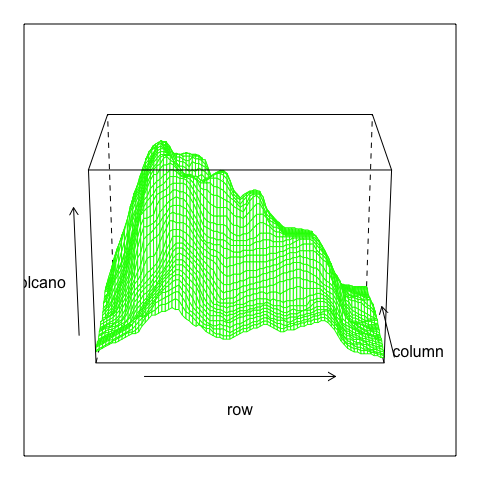

```r
lattice::wireframe(volcano, col = "green",
           screen = rglToLattice())
```

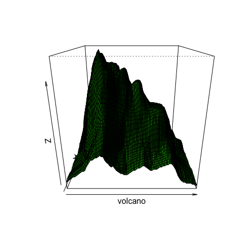

```r
angles <- rglToBase()
persp(volcano, col = "green", shade = TRUE,
      theta = angles$theta, phi = angles$phi)
```

Note that the `orientlib` package must be available for these functions to work.

## Warning: Work in Progress!

This vignette is in a preliminary form. Many aspects of the rgl package are not described, or do not have examples. There may even be functions that are missed completely, if the following list is not empty:

```
## character(0)
```

## Index of Functions

The following functions and constants are described in this document:

| gc3d | plotmath3d | rgl.pop | shapelist3d |  |
| --- | --- | --- | --- | --- |
| GramSchmidt | getWidgetId | points3d | rgl.postscript | show2d |
| Sweave.snapshot | getr3dDefaults | polygon3d | rgl.primitive | snapshot3d |
| abclines3d | grid3d | pop3d | rgl.projection | spheres3d |
| addNormals | highlevel | propertyControl | rgl.quads | spin3d |
| addToSubscene3d | hook_rgl | propertySetter | rgl.quit | sprites3d |
| ageControl | hook_webgl | propertySlider | rgl.select | subdivision3d |
| ageSetter | icosahedron3d | qmesh3d | rgl.select3d | subsceneInfo |
| arrow3d | identify3d | quads3d | rgl.set | subsceneList |
| as.mesh3d | identityMatrix | r3dDefaults | rgl.setMouseCallbacks | subsetControl |
| asEuclidean | layout3d | readOBJ | rgl.setWheelCallback | subsetSetter |
| asHomogeneous | legend3d | readSTL | rgl.snapshot | subsetSlider |
| asRow | light3d | registerSceneChange | rgl.spheres | surface3d |
| aspect3d | lines3d | renderPlaywidget | rgl.sprites | terrain3d |
| axes3d | lowlevel | renderRglwidget | rgl.surface | tetrahedron3d |
| axis3d | material3d | rgl.Sweave | rgl.texts | text3d |
| bbox3d | matrixSetter | rgl.Sweave.off | rgl.triangles | texts3d |
| bg3d | mfrow3d | rgl.abclines | rgl.useNULL | title3d |
| bgplot3d | mouseMode | rgl.attrib | rgl.user2window | tmesh3d |
| box3d | movie3d | rgl.attrib.count | rgl.viewpoint | toggleButton |
| clear3d | mtext3d | rgl.attrib.info | rgl.window2user | toggleWidget |
| clearSubsceneList | newSubscene3d | rgl.bbox | rglFonts | transform3d |
| clipplaneControl | next3d | rgl.bg | rglMouse | translate3d |
| clipplaneSlider | normalize.mesh3d | rgl.bringtotop | rglShared | translationMatrix |
| clipplanes3d | observer3d | rgl.clear | rglToBase | triangles3d |
| cube3d | octahedron3d | rgl.clipplanes | rglToLattice | triangulate |
| cuboctahedron3d | oh3d | rgl.close | rglwidget | turn3d |
| currentSubscene3d | open3d | rgl.cur | rglwidget | useSubscene3d |
| cylinder3d | par3d | rgl.dev.list | rglwidgetOutput | vertexControl |
| decorate3d | par3dinterp | rgl.getMouseCallbacks | rotate3d | vertexSetter |
| deform.mesh3d | par3dinterpControl | rgl.getWheelCallback | rotationMatrix | view3d |
| delFromSubscene3d | par3dinterpSetter | rgl.ids | scale3d | wire3d |
| deldir | particles3d | rgl.init | scaleMatrix | writeASY |
| divide.mesh3d | pch3d | rgl.light | scene3d | writeOBJ |
| dodecahedron3d | persp3d | rgl.lines | sceneChange | writePLY |
| dot3d | pipe | rgl.linestrips | segments3d | writeSTL |
| elementId2Prefix | planes3d | rgl.material | select3d | writeWebGL |
| ellipse3d | play3d | rgl.open | selectpoints3d |  |
| extrude3d | playwidget | rgl.pixels | setUserShaders |  |
| figHeight | playwidgetOutput | rgl.planes | setupKnitr |  |
| figWidth | plot3d | rgl.points | shade3d |  |